# Polynomial/Step regression, GAM exploration

Hajin Jang

11/18/2025

## Polynomial regression

```r
library(ISLR2)
library(boot)
library(ggplot2)
```

```r
set.seed(4)

delta <- rep(0, 10)

for (i in 1:10) {
    fit <- glm(wage ~ poly(age, i), data = Wage)
    delta[i] <- cv.glm(Wage, fit, K = 10)$delta[1]
}

which.min(delta)
```

```
## [1] 4
```

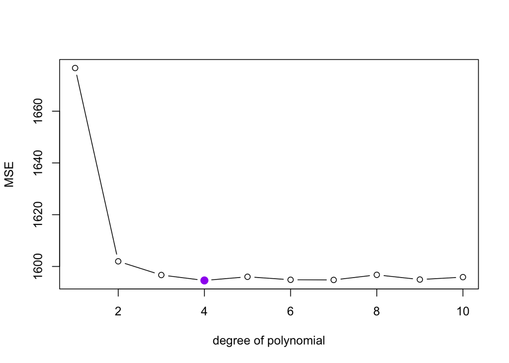

```r
plot(1:10, delta, type = "b", xlab = "degree of polynomial", ylab = "MSE")
points(which.min(delta), delta[which.min(delta)], col = "purple", cex = 2, pch = 20)
```

#### Fitting the model

```r
# best degree model
fit.best <- glm(wage ~ poly(age, 4),data=Wage)
summary(fit.best)
```

```
##
## Call:
## glm(formula = wage ~ poly(age, 4), data = Wage)
##
## Coefficients:
##                Estimate Std. Error t value Pr(>|t|)
## (Intercept)    111.7036     0.7287 153.283  < 2e-16 ***
## poly(age, 4)1  447.0679    39.9148  11.201  < 2e-16 ***
## poly(age, 4)2 -478.3158    39.9148 -11.983  < 2e-16 ***
## poly(age, 4)3  125.5217    39.9148   3.145  0.00168 **
## poly(age, 4)4  -77.9112    39.9148  -1.952  0.05104 .
## ---
## Signif. codes:  0 '***' 0.001 '**' 0.01 '*' 0.05 '.' 0.1 ' ' 1
##
## (Dispersion parameter for gaussian family taken to be 1593.19)
##
##     Null deviance: 5222086  on 2999  degrees of freedom
## Residual deviance: 4771604  on 2995  degrees of freedom
## AIC: 30641
##
## Number of Fisher Scoring iterations: 2
```

```r
# ANOVA
fit1 <- lm(wage ~ age, data = Wage)
fit2 <- lm(wage ~ poly(age, 2), data = Wage)
fit3 <- lm(wage ~ poly(age, 3), data = Wage)
fit4 <- lm(wage ~ poly(age, 4), data = Wage)
fit5 <- lm(wage ~ poly(age, 5), data = Wage)
fit6 <- lm(wage ~ poly(age, 6), data = Wage)
fit7 <- lm(wage ~ poly(age, 7), data = Wage)
fit8 <- lm(wage ~ poly(age, 8), data = Wage)
fit9 <- lm(wage ~ poly(age, 9), data = Wage)
fit10 <- lm(wage ~ poly(age, 10), data = Wage)
anova(fit1, fit2, fit3, fit4, fit5, fit6, fit7, fit8, fit9, fit10)
```

```
## Analysis of Variance Table
##
## Model  1: wage ~ age
## Model  2: wage ~ poly(age, 2)
## Model  3: wage ~ poly(age, 3)
## Model  4: wage ~ poly(age, 4)
## Model  5: wage ~ poly(age, 5)
## Model  6: wage ~ poly(age, 6)
## Model  7: wage ~ poly(age, 7)
## Model  8: wage ~ poly(age, 8)
## Model  9: wage ~ poly(age, 9)
## Model 10: wage ~ poly(age, 10)
##    Res.Df     RSS Df Sum of Sq        F    Pr(>F)
## 1    2998 5022216
## 2    2997 4793430  1    228786 143.7638 < 2.2e-16 ***
## 3    2996 4777674  1     15756   9.9005  0.001669 **
## 4    2995 4771604  1      6070   3.8143  0.050909 .
## 5    2994 4770322  1      1283   0.8059  0.369398
## 6    2993 4766389  1      3932   2.4709  0.116074
## 7    2992 4763834  1      2555   1.6057  0.205199
## 8    2991 4763707  1       127   0.0796  0.777865
## 9    2990 4756703  1      7004   4.4014  0.035994 *
## 10   2989 4756701  1         3   0.0017  0.967529
## ---
## Signif. codes:  0 '***' 0.001 '**' 0.01 '*' 0.05 '.' 0.1 ' ' 1
```

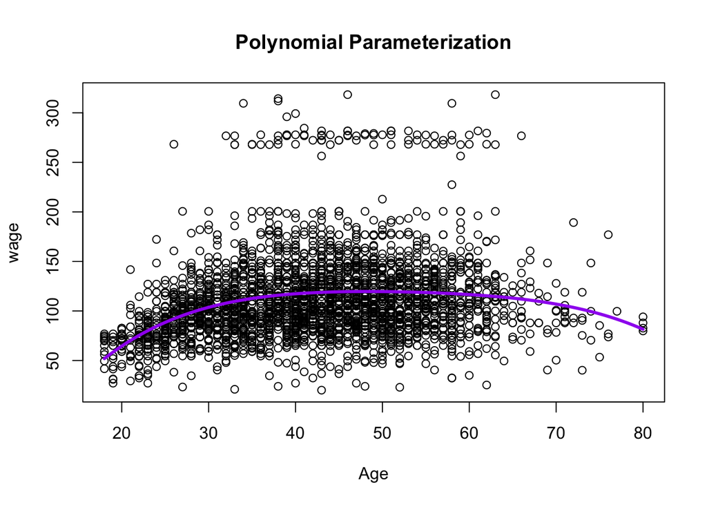

```r
# plot of the resulting polynomial fit to the data
## age grid
age.grid <- seq(from=min(Wage$age), to = max(Wage$age), length=100)
## predict weight for each age on the grid
age.pred <- predict(fit4, newdata=list(age=age.grid), se=TRUE)
## plot the relationship
plot(Wage$age, Wage$wage, xlim=c(min(Wage$age), max(Wage$age)), ylim=c(min(Wage$wage), max(Wage$wage)), xlab="Age", ylab="wage", main="Polynomial Parameterization")
lines(age.grid, age.pred$fit, col = "purple", lwd = 3)
```

**Comment:** The optimal degree selected using cross-validation is d=4, corresponding to the minimum MSE. This indicates that model performance did not noticeably improve beyond a 4th-degree polynomial. However, the ANOVA results showed that only degrees 2, 3, and 9 were statistically significant (p<0.05). Thus, the optimal degree determined by cross-validation differs from the results obtained through hypothesis testing with ANOVA.

#### Fitting a step function

```r
# I chose cut points from 2 to 10.
for (i in 2:10) {
  Wage$age.cut = cut(Wage$age, i)
  fit = glm(wage~age.cut, data=Wage)
  delta[i] = cv.glm(Wage, fit, K=10)$delta[1]
}

which.min(delta) # Best number of cuts is 8
```

```
## [1] 8
```

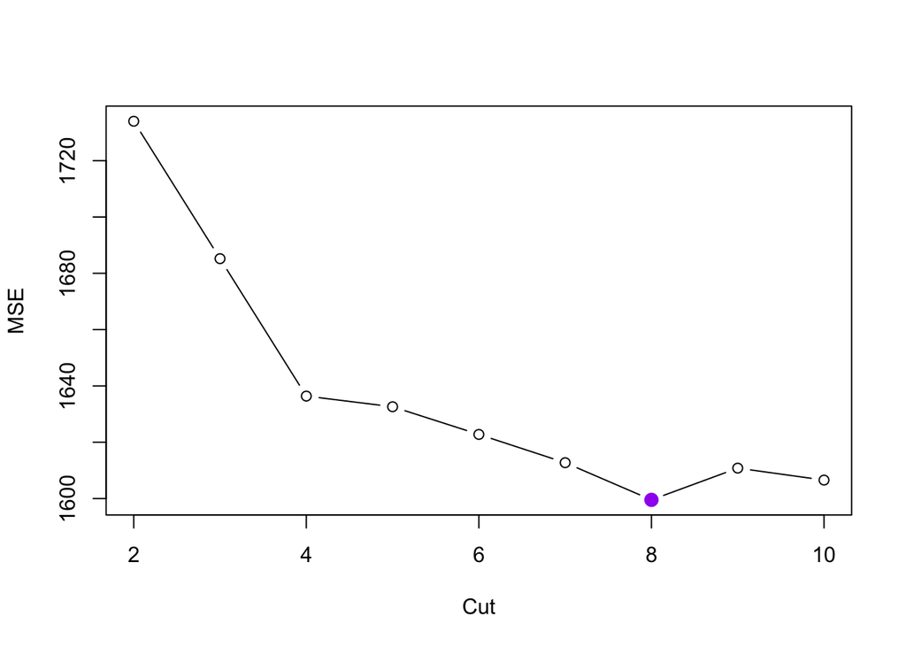

```r
plot(2:10, delta[-1], type = "b", xlab = "Cut", ylab = "MSE")
points(which.min(delta), delta[which.min(delta)], col = "purple", cex = 2, pch = 20)
```

```r
# best model
fit.cut.best <- glm(wage ~ cut(age, 8),data=Wage)
summary(fit.cut.best)
```

```
##
## Call:
## glm(formula = wage ~ cut(age, 8), data = Wage)
##
## Coefficients:
##                        Estimate Std. Error t value Pr(>|t|)
## (Intercept)              76.282      2.630  29.007  < 2e-16 ***
## cut(age, 8)(25.8,33.5]   25.833      3.161   8.172 4.44e-16 ***
## cut(age, 8)(33.5,41.2]   40.226      3.049  13.193  < 2e-16 ***
## cut(age, 8)(41.2,49]     43.501      3.018  14.412  < 2e-16 ***
## cut(age, 8)(49,56.8]     40.136      3.177  12.634  < 2e-16 ***
## cut(age, 8)(56.8,64.5]   44.102      3.564  12.373  < 2e-16 ***
## cut(age, 8)(64.5,72.2]   28.948      6.042   4.792 1.74e-06 ***
## cut(age, 8)(72.2,80.1]   15.224      9.781   1.556     0.12
## ---
## Signif. codes:  0 '***' 0.001 '**' 0.01 '*' 0.05 '.' 0.1 ' ' 1
##
## (Dispersion parameter for gaussian family taken to be 1597.576)
##
##     Null deviance: 5222086  on 2999  degrees of freedom
## Residual deviance: 4779946  on 2992  degrees of freedom
## AIC: 30652
##
## Number of Fisher Scoring iterations: 2
```

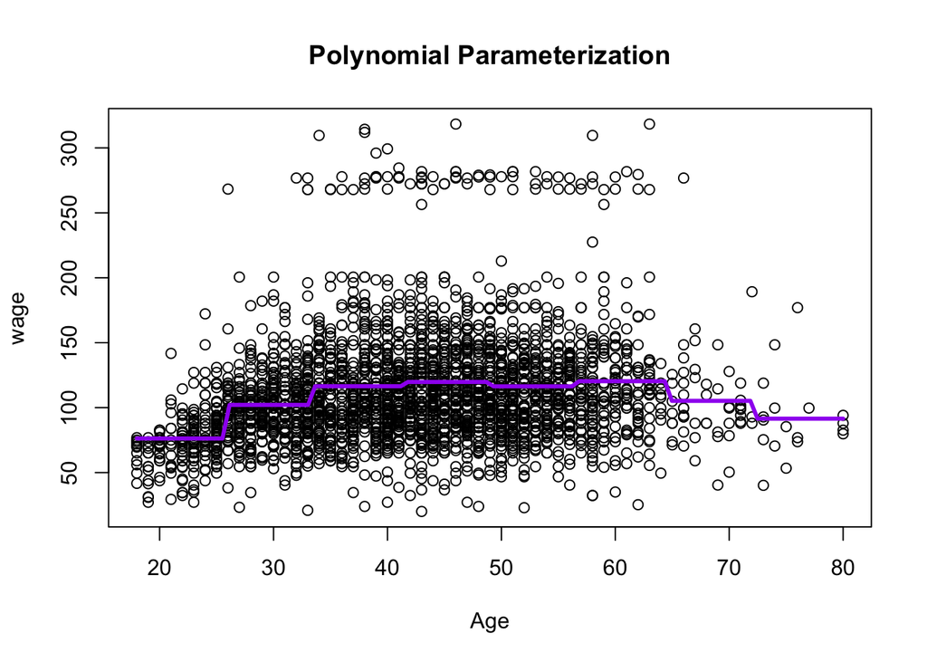

```r
# plot of the resulting polynomial fit to the data
## predict weight for each age on the grid
age.pred <- predict(fit.cut.best, data.frame(age=age.grid))
## plot the relationship
plot(Wage$age, Wage$wage, xlim=c(min(Wage$age), max(Wage$age)), ylim=c(min(Wage$wage), max(Wage$wage)), xlab="Age", ylab="wage", main="Polynomial Parameterization")
lines(age.grid, age.pred, col = "purple", lwd = 3)
```

**Comment:** The results show that the optimal number of cuts is 8, as it yields the lowest MSE based on cross-validation.

## Stepwise selection

```r
library(leaps)
library(gam)
head(College)
```

```
##                              Private Apps Accept Enroll Top10perc Top25perc
## Abilene Christian University     Yes 1660   1232    721        23        52
## Adelphi University               Yes 2186   1924    512        16        29
## Adrian College                   Yes 1428   1097    336        22        50
## Agnes Scott College              Yes  417    349    137        60        89
## Alaska Pacific University        Yes  193    146     55        16        44
## Albertson College                Yes  587    479    158        38        62
##                              F.Undergrad P.Undergrad Outstate Room.Board Books
## Abilene Christian University        2885         537     7440       3300   450
## Adelphi University                  2683        1227    12280       6450   750
## Adrian College                      1036          99    11250       3750   400
## Agnes Scott College                  510          63    12960       5450   450
## Alaska Pacific University            249         869     7560       4120   800
## Albertson College                    678          41    13500       3335   500
##                              Personal PhD Terminal S.F.Ratio perc.alumni Expend
## Abilene Christian University     2200  70       78      18.1          12   7041
## Adelphi University               1500  29       30      12.2          16  10527
## Adrian College                   1165  53       66      12.9          30   8735
## Agnes Scott College               875  92       97       7.7          37  19016
## Alaska Pacific University        1500  76       72      11.9           2  10922
## Albertson College                 675  67       73       9.4          11   9727
##                              Grad.Rate
## Abilene Christian University        60
## Adelphi University                  56
## Adrian College                      54
## Agnes Scott College                 59
## Alaska Pacific University           15
## Albertson College                   55
```

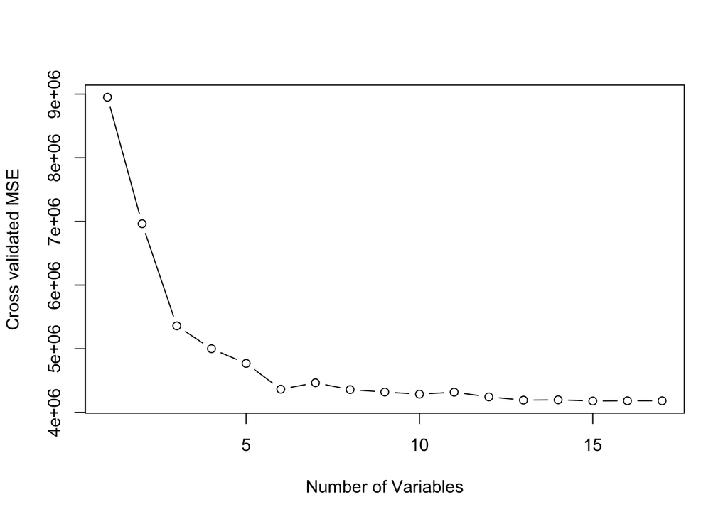

```r
set.seed(2)
index <- sample(1:2, nrow(College), replace = T, prob = c(0.7, 0.3))

train <- College[index == 1, ]
test <- College[index == 2, ]

col.fit.fwd <- regsubsets(Outstate ~ ., data = train, method = "forward")
fwd.summary <- summary(col.fit.fwd)

# Forward stepwise selection on the training set with cross validation
predict.regsubsets <- function(fitobj, data, id) {
  form <- as.formula(fitobj$call[[2]])
  mat  <- model.matrix(form, data)
  coefi <- coef(fitobj, id = id)
  xvars <- names(coefi)
  as.matrix(mat[, xvars]) %*% coefi
}

# set up k fold cross validation on the training data
set.seed(2)
k <- 10
folds <- sample(1:k, size = nrow(train), replace = TRUE)

nvmax <- ncol(train) - 1   # maximum number of predictors
cv.mse <- matrix(NA, nrow = k, ncol = nvmax)

for (j in 1:k) {
  # fit forward stepwise on the training folds
  fwd.fit.cv <- regsubsets(Outstate ~ .,
                           data   = train[folds != j, ],
                           method = "forward",
                           nvmax  = nvmax)
  # evaluate models of size 1, 2, ..., nvmax on the validation fold
  for (i in 1:nvmax) {
    pred <- predict.regsubsets(fwd.fit.cv,
                               data = train[folds == j, ],
                               id   = i)
    cv.mse[j, i] <- mean((train$Outstate[folds == j] - pred)^2)
  }
}

# average validation MSE for each model size
mean.cv.mse <- apply(cv.mse, 2, mean)
plot(mean.cv.mse, xlab = "Number of Variables",
     ylab = "Cross validated MSE", type = "b")
```

```r
best.size <- which.min(mean.cv.mse)
best.size
```

```
## [1] 15
```

```r
# refit forward stepwise on the full training set using the chosen size
col.fit.fwd.final <- regsubsets(Outstate ~ .,
                                data   = train,
                                method = "forward",
                                nvmax  = best.size)

best.model <- coef(col.fit.fwd.final, best.size)
print(best.model)
```

```
##   (Intercept)    PrivateYes          Apps        Accept        Enroll
## -1.562187e+03  2.073162e+03 -2.130830e-01  9.324383e-01 -1.300064e+00
##     Top10perc   F.Undergrad    Room.Board         Books      Personal
##  1.890624e+01 -6.424084e-02  8.503493e-01 -3.545951e-01 -1.086153e-01
##           PhD      Terminal     S.F.Ratio   perc.alumni        Expend
##  1.181897e+01  2.317168e+01 -4.711382e+01  4.679812e+01  2.019631e-01
##     Grad.Rate
##  2.352147e+01
```

**Comment:** Using 10 fold cross validation on the training set, the model with 15 predictors achieved the lowest validation MSE. I refitted a forward stepwise model with 15 variables on the full training data and found the final coefficients above.

#### Fitting a GAM

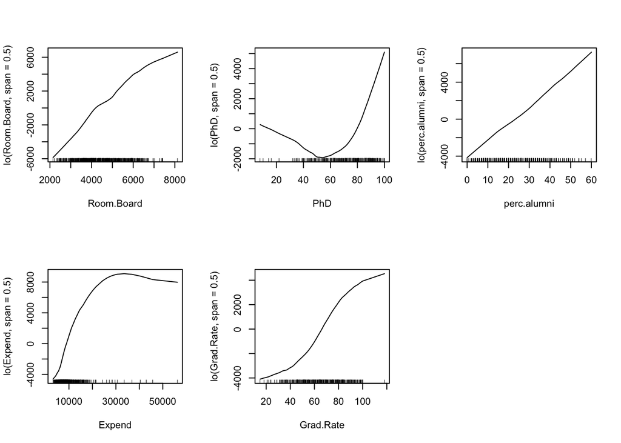

```r
gam.lo.room <-gam(Outstate~lo(Room.Board, span=0.5), data=train)
gam.lo.PhD <-gam(Outstate~lo(PhD, span=0.5), data=train)
gam.lo.perc.alumni <-gam(Outstate~lo(perc.alumni, span=0.5), data=train)
gam.lo.Expend <-gam(Outstate~lo(Expend, span=0.5), data=train)
gam.lo.Grad.Rate <-gam(Outstate~lo(Grad.Rate, span=0.5), data=train)

par(mfrow = c(2,3))
plot.Gam(gam.lo.room);plot.Gam(gam.lo.PhD);plot.Gam(gam.lo.perc.alumni);plot.Gam(gam.lo.Expend);plot.Gam(gam.lo.Grad.Rate)
```

**Comment:** Based on the local regression plots,

*Room.Board:* The relationship appears nearly linear, showing a slight upward trend as Room.Board increases.

*PhD:* The pattern is clearly non-linear, showing a U-shaped curve, suggesting that including a quadratic term would capture this relationship well.

*perc.alumni:* The trend increases roughly linearly, so a simple linear model should be appropriate.

*Expend:* The curve rises sharply at lower values and then levels off, indicating that a log transformation or spline could better model this pattern.

*Grad.Rate:* The relationship looks almost exponential, with a sharp increase as Grad.Rate grows; a quadratic or spline model may better represent this trend.

##### Checking degrees of freedom

```r
#Check cv df for Room.Board
room.sspcv1 <- smooth.spline(train$Room.Board, train$Outstate, cv = T)
room.sspcv2 <- smooth.spline(train$Room.Board, train$Outstate, cv = F)
room.sspcv1$df; room.sspcv2$df # df of 7 would be suitable
```

```
## [1] 6.554703
```

```
## [1] 7.241589
```

```r
# check cv df for PhD
PhD.sspcv1 <- smooth.spline(train$PhD, train$Outstate, cv = T)
PhD.sspcv2 <- smooth.spline(train$PhD, train$Outstate, cv = F)
PhD.sspcv1$df; PhD.sspcv2$df # df of 5 would be suitable
```

```
## [1] 5.776143
```

```
## [1] 4.649206
```

```r
# check cv df for perc.alumni
perc.sspcv1 <- smooth.spline(train$perc.alumni, train$Outstate, cv = T)
perc.sspcv2 <- smooth.spline(train$perc.alumni, train$Outstate, cv = F)
perc.sspcv1$df; perc.sspcv2$df # df of 2 would be suitable
```

```
## [1] 2.000194
```

```
## [1] 2.000194
```

```r
# check cv df for Expend
Expend.sspcv1 <- smooth.spline(train$Expend, train$Outstate, cv = T)
Expend.sspcv2 <- smooth.spline(train$Expend, train$Outstate, cv = F)
Expend.sspcv1$df; Expend.sspcv2$df # df of 6 would be suitable
```

```
## [1] 5.276429
```

```
## [1] 7.33188
```

```r
# check cv df for Grad.Rate
Grad.sspcv1 <- smooth.spline(train$Grad.Rate, train$Outstate, cv = T)
Grad.sspcv2 <- smooth.spline(train$Grad.Rate, train$Outstate, cv = F)
Grad.sspcv1$df; Grad.sspcv2$df # df of 7 would be suitable
```

```
## [1] 7.145169
```

```
## [1] 6.520131
```

**Comment:** The degree of freedom from cross-validation and generalized cross-validation are quite similar, so it’s reasonable to select the df value that is closest between the two methods.

##### Model1 - Smooth splines

```r
## fit a gam
col.fit.gam1 <- gam(Outstate ~ Private + s(Room.Board, 7) + s(PhD, 5) + s(perc.alumni, 2) +
  s(Expend, 6) + s(Grad.Rate, 7), data = train)
summary(col.fit.gam1)
```

```
##
## Call: gam(formula = Outstate ~ Private + s(Room.Board, 7) + s(PhD,
##     5) + s(perc.alumni, 2) + s(Expend, 6) + s(Grad.Rate, 7),
##     data = train)
## Deviance Residuals:
##      Min       1Q   Median       3Q      Max
## -7738.24 -1053.34    57.85  1229.89  7011.57
##
## (Dispersion Parameter for gaussian family taken to be 3429183)
##
##     Null Deviance: 8506861746 on 538 degrees of freedom
## Residual Deviance: 1748886978 on 510.0011 degrees of freedom
## AIC: 9670.587
##
## Number of Local Scoring Iterations: NA
##
## Anova for Parametric Effects
##                    Df     Sum Sq    Mean Sq F value    Pr(>F)
## Private             1 2044397750 2044397750 596.176 < 2.2e-16 ***
## s(Room.Board, 7)    1 1731196288 1731196288 504.842 < 2.2e-16 ***
## s(PhD, 5)           1  488533862  488533862 142.464 < 2.2e-16 ***
## s(perc.alumni, 2)   1  328437722  328437722  95.777 < 2.2e-16 ***
## s(Expend, 6)        1  858858022  858858022 250.456 < 2.2e-16 ***
## s(Grad.Rate, 7)     1  111873709  111873709  32.624 1.902e-08 ***
## Residuals         510 1748886978    3429183
## ---
## Signif. codes:  0 '***' 0.001 '**' 0.01 '*' 0.05 '.' 0.1 ' ' 1
##
## Anova for Nonparametric Effects
##                   Npar Df  Npar F   Pr(F)
## (Intercept)
## Private
## s(Room.Board, 7)        6  2.6754 0.01449 *
## s(PhD, 5)               4  2.8766 0.02241 *
## s(perc.alumni, 2)       1  1.6081 0.20534
## s(Expend, 6)            5 18.5453 < 2e-16 ***
## s(Grad.Rate, 7)         6  2.5284 0.02020 *
## ---
## Signif. codes:  0 '***' 0.001 '**' 0.01 '*' 0.05 '.' 0.1 ' ' 1
```

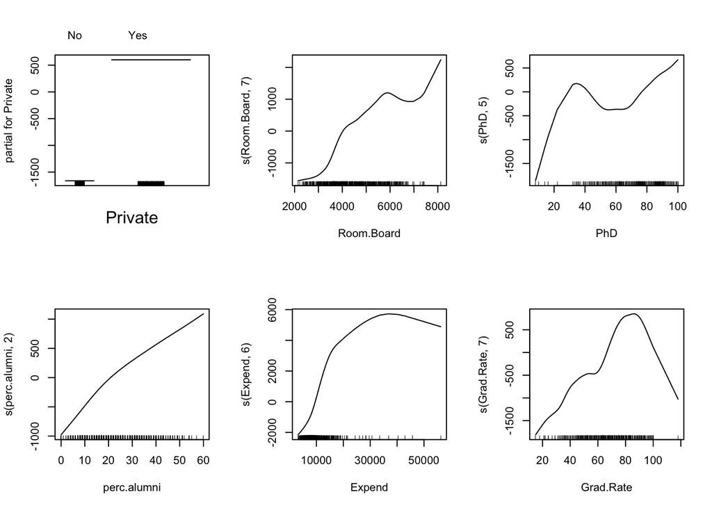

```r
## plot
par(mfrow = c(2,3))
plot.Gam(col.fit.gam1)
```

```r
## mse
pred1 <- predict(col.fit.gam1, test)
mse1 <- mean( (pred1-test$Outstate)^2)
mse1
```

```
## [1] 3570034
```

##### Model2 - Natural splines

```r
## fit a gam
col.fit.gam2 <- gam(Outstate ~ Private + ns(Room.Board, 7) + ns(PhD, 5) + ns(perc.alumni, 2) +
  ns(Expend, 6) + ns(Grad.Rate, 7), data = train)
summary(col.fit.gam2)
```

```
##
## Call: gam(formula = Outstate ~ Private + ns(Room.Board, 7) + ns(PhD,
##     5) + ns(perc.alumni, 2) + ns(Expend, 6) + ns(Grad.Rate, 7),
##     data = train)
## Deviance Residuals:
##      Min       1Q   Median       3Q      Max
## -7752.98 -1032.12    19.28  1233.40  7299.21
##
## (Dispersion Parameter for gaussian family taken to be 3493181)
##
##     Null Deviance: 8506861746 on 538 degrees of freedom
## Residual Deviance: 1781522300 on 510 degrees of freedom
## AIC: 9680.555
##
## Number of Local Scoring Iterations: 2
##
## Anova for Parametric Effects
##                     Df     Sum Sq    Mean Sq F value    Pr(>F)
## Private              1 2335485186 2335485186 668.584 < 2.2e-16 ***
## ns(Room.Board, 7)    7 2276042990  325148999  93.081 < 2.2e-16 ***
## ns(PhD, 5)           5  911859749  182371950  52.208 < 2.2e-16 ***
## ns(perc.alumni, 2)   2  385600909  192800455  55.193 < 2.2e-16 ***
## ns(Expend, 6)        6  664672777  110778796  31.713 < 2.2e-16 ***
## ns(Grad.Rate, 7)     7  151677835   21668262   6.203 5.499e-07 ***
## Residuals          510 1781522300    3493181
## ---
## Signif. codes:  0 '***' 0.001 '**' 0.01 '*' 0.05 '.' 0.1 ' ' 1
```

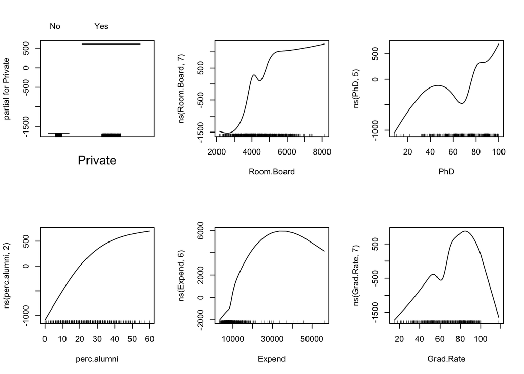

```r
## plot
par(mfrow = c(2,3))
plot.Gam(col.fit.gam2)
```

```r
## mse
pred2 <- predict(col.fit.gam2, test)
mse2 <- mean( (pred2-test$Outstate)^2)
mse2
```

```
## [1] 3715506
```

##### Model3 - Cubic splines

```r
## fit a gam
col.fit.gam3 <- gam(Outstate ~ Private + bs(Room.Board, 7) + bs(PhD, 5) + bs(perc.alumni, 2) +
  bs(Expend, 6) + bs(Grad.Rate, 7), data = train)
summary(col.fit.gam3)
```

```
##
## Call: gam(formula = Outstate ~ Private + bs(Room.Board, 7) + bs(PhD,
##     5) + bs(perc.alumni, 2) + bs(Expend, 6) + bs(Grad.Rate, 7),
##     data = train)
## Deviance Residuals:
##      Min       1Q   Median       3Q      Max
## -7922.05 -1022.97    36.09  1227.78  6672.34
##
## (Dispersion Parameter for gaussian family taken to be 3455380)
##
##     Null Deviance: 8506861746 on 538 degrees of freedom
## Residual Deviance: 1758788259 on 509 degrees of freedom
## AIC: 9675.632
##
## Number of Local Scoring Iterations: 2
##
## Anova for Parametric Effects
##                     Df     Sum Sq    Mean Sq  F value    Pr(>F)
## Private              1 2335485186 2335485186 675.8983 < 2.2e-16 ***
## bs(Room.Board, 7)    7 2256685566  322383652  93.2991 < 2.2e-16 ***
## bs(PhD, 5)           5  938008908  187601782  54.2927 < 2.2e-16 ***
## bs(perc.alumni, 2)   3  389084288  129694763  37.5342 < 2.2e-16 ***
## bs(Expend, 6)        6  673655985  112275997  32.4931 < 2.2e-16 ***
## bs(Grad.Rate, 7)     7  155153553   22164793   6.4146 2.998e-07 ***
## Residuals          509 1758788259    3455380
## ---
## Signif. codes:  0 '***' 0.001 '**' 0.01 '*' 0.05 '.' 0.1 ' ' 1
```

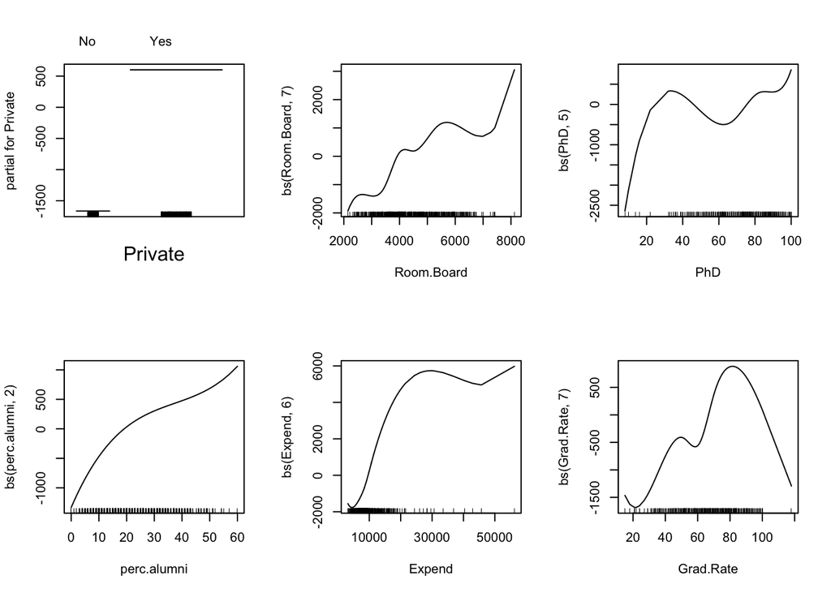

```r
## plot
par(mfrow = c(2,3))
plot.Gam(col.fit.gam3)
```

```r
## mse
pred3 <- predict(col.fit.gam3, test)
mse3 <- mean( (pred3-test$Outstate)^2)
mse3
```

```
## [1] 3699267
```

##### Model4 - Linear (room, perc); Quadratic (PhD); Log (Expend); Spline (Grad)

```r
## fit a gam
col.fit.gam4 <- gam(Outstate ~ Private + Room.Board + poly(PhD, 2) + perc.alumni +
  log(Expend) + s(Grad.Rate, 7), data = train)
summary(col.fit.gam4)
```

```
##
## Call: gam(formula = Outstate ~ Private + Room.Board + poly(PhD, 2) +
##     perc.alumni + log(Expend) + s(Grad.Rate, 7), data = train)
## Deviance Residuals:
##      Min       1Q   Median       3Q      Max
## -7248.11 -1247.61    24.35  1283.57  8928.43
##
## (Dispersion Parameter for gaussian family taken to be 3813316)
##
##     Null Deviance: 8506861746 on 538 degrees of freedom
## Residual Deviance: 2001992806 on 525.0005 degrees of freedom
## AIC: 9713.442
##
## Number of Local Scoring Iterations: NA
##
## Anova for Parametric Effects
##                  Df     Sum Sq    Mean Sq F value    Pr(>F)
## Private           1 2295534529 2295534529 601.979 < 2.2e-16 ***
## Room.Board        1 2165269674 2165269674 567.818 < 2.2e-16 ***
## poly(PhD, 2)      2  890224898  445112449 116.726 < 2.2e-16 ***
## perc.alumni       1  398511237  398511237 104.505 < 2.2e-16 ***
## log(Expend)       1  532765282  532765282 139.712 < 2.2e-16 ***
## s(Grad.Rate, 7)   1  113083979  113083979  29.655 7.941e-08 ***
## Residuals       525 2001992806    3813316
## ---
## Signif. codes:  0 '***' 0.001 '**' 0.01 '*' 0.05 '.' 0.1 ' ' 1
##
## Anova for Nonparametric Effects
##                 Npar Df Npar F   Pr(F)
## (Intercept)
## Private
## Room.Board
## poly(PhD, 2)
## perc.alumni
## log(Expend)
## s(Grad.Rate, 7)       6  2.408 0.02639 *
## ---
## Signif. codes:  0 '***' 0.001 '**' 0.01 '*' 0.05 '.' 0.1 ' ' 1
```

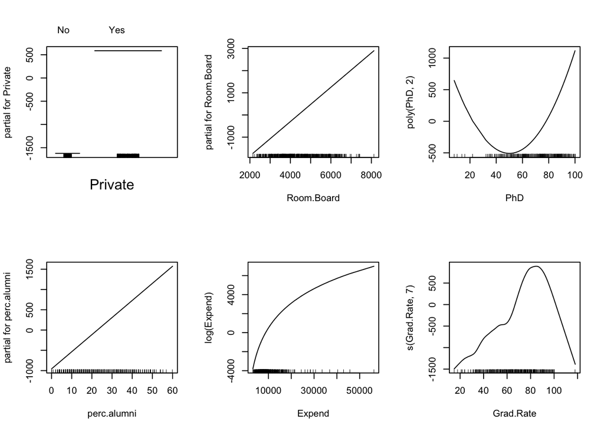

```r
## plot
par(mfrow = c(2,3))
plot.Gam(col.fit.gam4)
```

```r
## mse
pred4 <- predict(col.fit.gam4, test)
mse4 <- mean( (pred4-test$Outstate)^2)
mse4
```

```
## [1] 3592909
```

##### Model5 - Linear (room, perc); Quadratic (PhD); Spline (Expend, Grad)

```r
## fit a gam
col.fit.gam5 <- gam(Outstate ~ Private + Room.Board + poly(PhD, 2) + perc.alumni +
  s(Expend, 6) + s(Grad.Rate, 7), data = train)
summary(col.fit.gam5)
```

```
##
## Call: gam(formula = Outstate ~ Private + Room.Board + poly(PhD, 2) +
##     perc.alumni + s(Expend, 6) + s(Grad.Rate, 7), data = train)
## Deviance Residuals:
##      Min       1Q   Median       3Q      Max
## -7437.02 -1106.38    52.21  1313.69  7955.78
##
## (Dispersion Parameter for gaussian family taken to be 3552928)
##
##     Null Deviance: 8506861746 on 538 degrees of freedom
## Residual Deviance: 1847525350 on 520.0008 degrees of freedom
## AIC: 9680.161
##
## Number of Local Scoring Iterations: NA
##
## Anova for Parametric Effects
##                  Df     Sum Sq    Mean Sq F value    Pr(>F)
## Private           1 2058920281 2058920281 579.500 < 2.2e-16 ***
## Room.Board        1 1740579210 1740579210 489.900 < 2.2e-16 ***
## poly(PhD, 2)      2  643302653  321651327  90.531 < 2.2e-16 ***
## perc.alumni       1  343592748  343592748  96.707 < 2.2e-16 ***
## s(Expend, 6)      1  696652474  696652474 196.078 < 2.2e-16 ***
## s(Grad.Rate, 7)   1  124054010  124054010  34.916  6.23e-09 ***
## Residuals       520 1847525350    3552928
## ---
## Signif. codes:  0 '***' 0.001 '**' 0.01 '*' 0.05 '.' 0.1 ' ' 1
##
## Anova for Nonparametric Effects
##                 Npar Df Npar F     Pr(F)
## (Intercept)
## Private
## Room.Board
## poly(PhD, 2)
## perc.alumni
## s(Expend, 6)          5  17.33 6.661e-16 ***
## s(Grad.Rate, 7)       6   2.34    0.0307 *
## ---
## Signif. codes:  0 '***' 0.001 '**' 0.01 '*' 0.05 '.' 0.1 ' ' 1
```

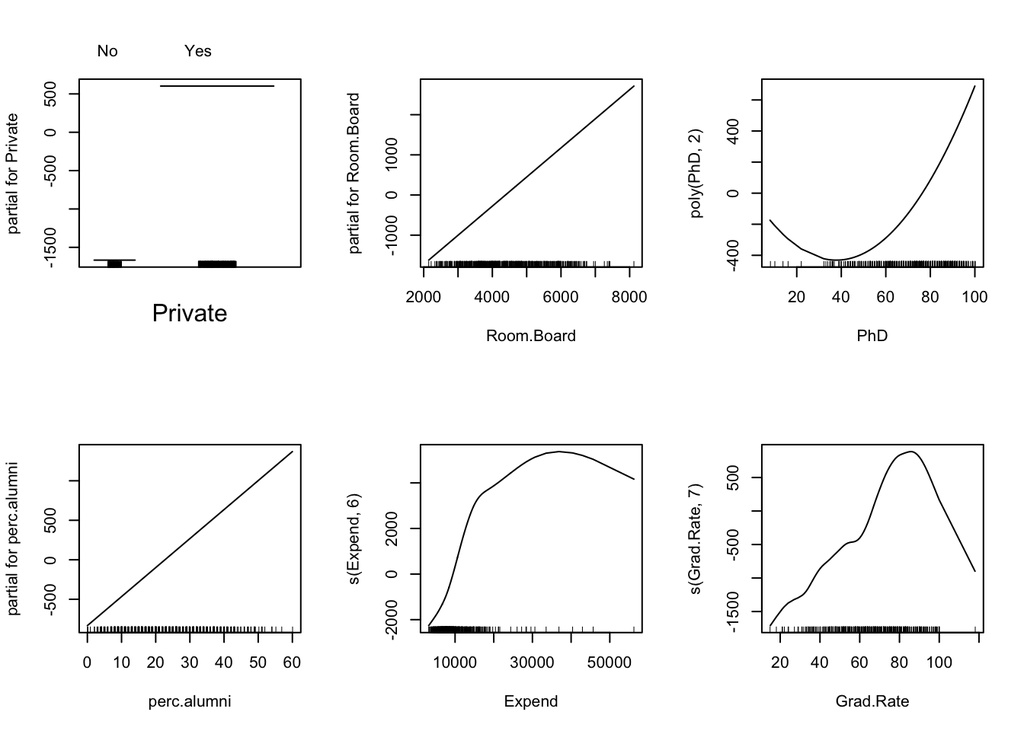

```r
## plot
par(mfrow = c(2,3))
plot.Gam(col.fit.gam5)
```

```r
## mse
pred5 <- predict(col.fit.gam5, test)
mse5 <- mean( (pred5-test$Outstate)^2)
mse5
```

```
## [1] 3395978
```

##### Model6 - Linear (room, perc); Spline (PhD, Expend, Grad)

```r
## fit a gam
col.fit.gam6 <- gam(Outstate ~ Private + Room.Board + s(PhD, 5) + perc.alumni +
  s(Expend, 6) + s(Grad.Rate, 7), data = train)
summary(col.fit.gam6)
```

```
##
## Call: gam(formula = Outstate ~ Private + Room.Board + s(PhD, 5) + perc.alumni +
##     s(Expend, 6) + s(Grad.Rate, 7), data = train)
## Deviance Residuals:
##      Min       1Q   Median       3Q      Max
## -7399.60 -1068.74    48.55  1287.51  7321.99
##
## (Dispersion Parameter for gaussian family taken to be 3491648)
##
##     Null Deviance: 8506861746 on 538 degrees of freedom
## Residual Deviance: 1805184610 on 517.0008 degrees of freedom
## AIC: 9673.665
##
## Number of Local Scoring Iterations: NA
##
## Anova for Parametric Effects
##                  Df     Sum Sq    Mean Sq F value    Pr(>F)
## Private           1 2059629394 2059629394 589.873 < 2.2e-16 ***
## Room.Board        1 1700514270 1700514270 487.023 < 2.2e-16 ***
## s(PhD, 5)         1  490344166  490344166 140.434 < 2.2e-16 ***
## perc.alumni       1  340006081  340006081  97.377 < 2.2e-16 ***
## s(Expend, 6)      1  799140075  799140075 228.872 < 2.2e-16 ***
## s(Grad.Rate, 7)   1  122761972  122761972  35.159 5.562e-09 ***
## Residuals       517 1805184610    3491648
## ---
## Signif. codes:  0 '***' 0.001 '**' 0.01 '*' 0.05 '.' 0.1 ' ' 1
##
## Anova for Nonparametric Effects
##                 Npar Df  Npar F     Pr(F)
## (Intercept)
## Private
## Room.Board
## s(PhD, 5)             4  3.4840  0.008038 **
## perc.alumni
## s(Expend, 6)          5 18.6235 < 2.2e-16 ***
## s(Grad.Rate, 7)       6  2.5527  0.019112 *
## ---
## Signif. codes:  0 '***' 0.001 '**' 0.01 '*' 0.05 '.' 0.1 ' ' 1
```

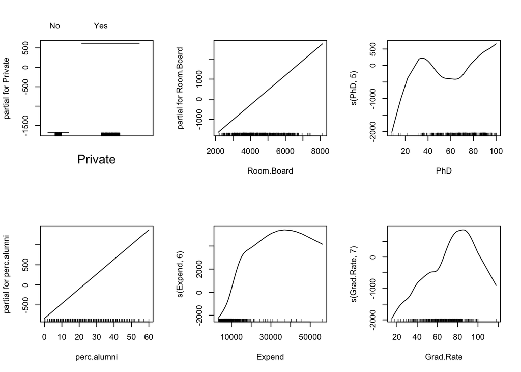

```r
## plot
par(mfrow = c(2,3))
plot.Gam(col.fit.gam6)
```

```r
## mse
pred6 <- predict(col.fit.gam6, test)
mse6 <- mean( (pred6-test$Outstate)^2)
mse6
```

```
## [1] 3482550
```

##### Model7 - Linear (room, perc); Spline (PhD, Grad); Log (Expend)

```r
## fit a gam
col.fit.gam7 <- gam(Outstate ~ Private + Room.Board + s(PhD, 5) + perc.alumni +
  log(Expend) + s(Grad.Rate, 7), data = train)
summary(col.fit.gam7)
```

```
##
## Call: gam(formula = Outstate ~ Private + Room.Board + s(PhD, 5) + perc.alumni +
##     log(Expend) + s(Grad.Rate, 7), data = train)
## Deviance Residuals:
##      Min       1Q   Median       3Q      Max
## -7130.25 -1218.78    55.77  1203.86  8308.20
##
## (Dispersion Parameter for gaussian family taken to be 3744477)
##
##     Null Deviance: 8506861746 on 538 degrees of freedom
## Residual Deviance: 1954618530 on 522.0005 degrees of freedom
## AIC: 9706.533
##
## Number of Local Scoring Iterations: NA
##
## Anova for Parametric Effects
##                  Df     Sum Sq    Mean Sq F value    Pr(>F)
## Private           1 2263749298 2263749298 604.557 < 2.2e-16 ***
## Room.Board        1 2044039366 2044039366 545.881 < 2.2e-16 ***
## s(PhD, 5)         1  666094628  666094628 177.887 < 2.2e-16 ***
## perc.alumni       1  395725740  395725740 105.683 < 2.2e-16 ***
## log(Expend)       1  634436643  634436643 169.433 < 2.2e-16 ***
## s(Grad.Rate, 7)   1  110592191  110592191  29.535 8.441e-08 ***
## Residuals       522 1954618530    3744477
## ---
## Signif. codes:  0 '***' 0.001 '**' 0.01 '*' 0.05 '.' 0.1 ' ' 1
##
## Anova for Nonparametric Effects
##                 Npar Df Npar F     Pr(F)
## (Intercept)
## Private
## Room.Board
## s(PhD, 5)             4 4.8560 0.0007485 ***
## perc.alumni
## log(Expend)
## s(Grad.Rate, 7)       6 2.6155 0.0165746 *
## ---
## Signif. codes:  0 '***' 0.001 '**' 0.01 '*' 0.05 '.' 0.1 ' ' 1
```

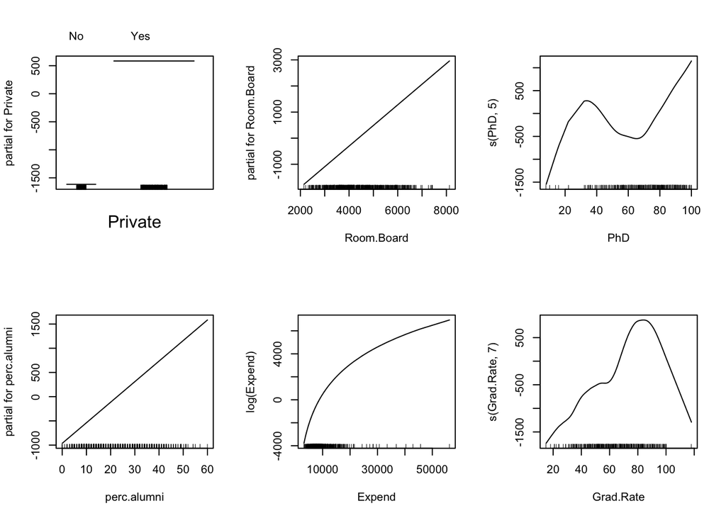

```r
## plot
par(mfrow = c(2,3))
plot.Gam(col.fit.gam7)
```

```r
## mse
pred7 <- predict(col.fit.gam7, test)
mse7 <- mean( (pred7-test$Outstate)^2)
mse7
```

```
## [1] 3697370
```

##### Model8 - Linear (room, perc); Spline (PhD, Expend); Quadratic (Grad)

```r
## fit a gam
col.fit.gam8 <- gam(Outstate ~ Private + Room.Board + s(PhD, 5) + perc.alumni +
  s(Expend, 6) + poly(Grad.Rate, 2), data = train)
summary(col.fit.gam8)
```

```
##
## Call: gam(formula = Outstate ~ Private + Room.Board + s(PhD, 5) + perc.alumni +
##     s(Expend, 6) + poly(Grad.Rate, 2), data = train)
## Deviance Residuals:
##      Min       1Q   Median       3Q      Max
## -7346.84 -1036.46    62.88  1264.48  7204.24
##
## (Dispersion Parameter for gaussian family taken to be 3536489)
##
##     Null Deviance: 8506861746 on 538 degrees of freedom
## Residual Deviance: 1846048152 on 522.0003 degrees of freedom
## AIC: 9675.731
##
## Number of Local Scoring Iterations: NA
##
## Anova for Parametric Effects
##                     Df     Sum Sq    Mean Sq F value    Pr(>F)
## Private              1 2081513752 2081513752 588.582 < 2.2e-16 ***
## Room.Board           1 1705769496 1705769496 482.334 < 2.2e-16 ***
## s(PhD, 5)            1  522639798  522639798 147.785 < 2.2e-16 ***
## perc.alumni          1  344056373  344056373  97.288 < 2.2e-16 ***
## s(Expend, 6)         1  759891308  759891308 214.872 < 2.2e-16 ***
## poly(Grad.Rate, 2)   2  125014402   62507201  17.675 3.738e-08 ***
## Residuals          522 1846048152    3536489
## ---
## Signif. codes:  0 '***' 0.001 '**' 0.01 '*' 0.05 '.' 0.1 ' ' 1
##
## Anova for Nonparametric Effects
##                    Npar Df Npar F   Pr(F)
## (Intercept)
## Private
## Room.Board
## s(PhD, 5)                4  3.181 0.01343 *
## perc.alumni
## s(Expend, 6)             5 19.708 < 2e-16 ***
## poly(Grad.Rate, 2)
## ---
## Signif. codes:  0 '***' 0.001 '**' 0.01 '*' 0.05 '.' 0.1 ' ' 1
```

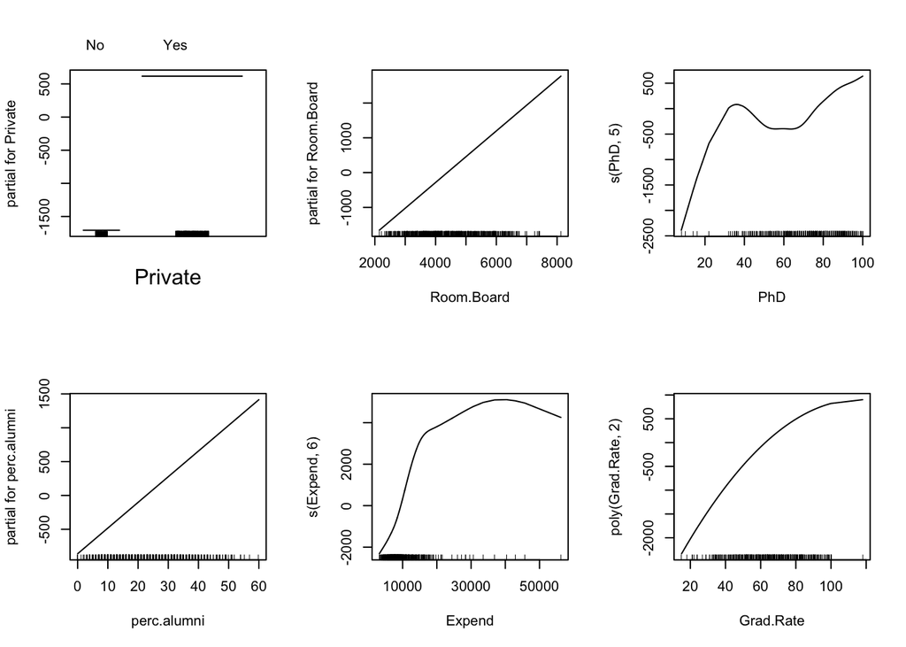

```r
## plot
par(mfrow = c(2,3))
plot.Gam(col.fit.gam8)
```

```r
## mse
pred8 <- predict(col.fit.gam8, test)
mse8 <- mean( (pred8-test$Outstate)^2)
mse8
```

```
## [1] 3423658
```

##### Compare MSE

```r
mse <- c(mse1, mse2, mse3, mse4, mse5, mse6, mse7, mse8)
mse
```

```
## [1] 3570034 3715506 3699267 3592909 3395978 3482550 3697370 3423658
```

```r
which.min(mse)
```

```
## [1] 5
```

**Comment:** Model 5, which applies linear terms for room and perc, quadratic for PhD, spline for Expend and Grad, achieved the lowest MSE, making it the best model.

In this question, I first used local regression for each numeric predictor to explore the shape of its relationship with the outcome and assess whether a parametric model could represent it well. Then, I applied cross-validation with smooth.spline() to determine the optimal df. Using these results, I fitted a series of GAMs where each numeric variable was modeled with smoothing, natural, or cubic splines based on the selected df. After that, I constructed the final GAM according to the observed relationship patterns and compared models using MSE to identify the best one.

From the plots, Model 5 accurately captures the associations between predictors and out-of-state tuition. Linear terms for room and perc effectively describe their steady upward trends. The quadratic term for PhD represents the U-shaped pattern, where tuition decreases and then rises with increasing faculty PhD percentages. The spline for Expend (6 df) captures the steep initial rise and subsequent plateau, while the spline for Grad (7 df) models the sharp tuition increase at higher graduation rates.

Overall, this model (combining linear, quadratic, and spline terms) offers a strong balance between flexibility and interpretability, and its low MSE indicates superior predictive performance.

#### Model evaluation (test set)

```r
# prediction function for regsubsets objects
predict.regsubsets <- function(fitobj, data, id) {
  form  <- as.formula(fitobj$call[[2]])
  mat   <- model.matrix(form, data)
  coefi <- coef(fitobj, id = id)
  xvars <- names(coefi)
  as.matrix(mat[, xvars]) %*% coefi
}

## Forward stepwise CV selected model
pred_fwd <- predict.regsubsets(col.fit.fwd.final, data = test, id = best.size)
mse_fwd  <- mean((test$Outstate - pred_fwd)^2)

## Final GAM model
pred_final <- predict(col.fit.gam5, newdata = test)
mse_final  <- mean((test$Outstate - pred_final)^2)

mse_fwd
```

```
## [1] 3912263
```

```r
mse_final
```

```
## [1] 3395978
```

**Comment:** For model selection, I compared the test MSE from the cross validated forward stepwise model with the test MSE of Model 5. The GAM model produced the lower test error, so Model 5 was selected as the final model (test MSE for Model 5 = 3395978 < 3912263).

Private and room maintain strong linear effects, both with highly significant p-values (p < 2.2e-16). The quadratic term for PhD effectively captures the non-linear trend, significantly improving model fit (p < 2.2e-16). Perc also remains a significant positive predictor of tuition (p < 2.2e-16). The non-linear spline for Expend successfully models the complex relationship between institutional spending and tuition (p < 2e-16). The spline for Grad contributes additional improvement to model fit, though its effect is comparatively weaker (p = 0.0307).

The MSE of 3395978 represents the average squared difference between predicted and actual tuition values on the test set. The deviance residuals, ranging from -7437 to 7956, suggest the model captures most of the data’s variability. Furthermore, the Residual Deviance (1847525350) is greatly reduced compared to the Null Deviance (8506861746), indicating that the model explains a substantial proportion of the variance in tuition.

#### Evidence of a non-linear relationship

Results from the GAM ANOVA provided clear evidence of non-linear relationships for several predictors. The spline for Expend showed a strong non-linear effect (edf = 5, F = 17.33, p = 6.661e-16). Grad.Rate also showed a significant non-linear effect (edf = 6, F = 2.34, p = 0.0307). PhD showed the significant quadratic term (overall F = 90.53, p < 2.2e-16). In contrast, Room.Board and perc.alumni had linear effects only (Df = 1, both p < 2.2e-16), indicating no evidence of additional non-linear structure for these variables.